# Environmental data downloading and processing

Moritz Klaassen

This walkthrough shows a reproducible pipeline for working with marine environmental data in R. By the end you’ll have:

- Imported local raster and vector layers.
- Discovered and downloaded global marine predictor variables with sdmpredictors.
- Learned to crop rasters to any region
- Combined presence–absence (PA) points with extracted environmental values.
- Saved a tidy CSV ready for species distribution modelling.

Most chunks are self-contained and can be run one-by-one. Feel free to adapt paths, layer codes, or regions to match your own project.

For this part, you will need the following packages: We rely on the terra package for raster operations and sdmpredictors to download our environmental data

```r
library(terra)
library(sdmpredictors)
```

Set working directory

```r
setwd(dirname(rstudioapi::getActiveDocumentContext()$path))
```

# Import local raster layers

Firstly, if we have our environmental data already downloaded, we can simply load it into our session. This includes a variety of file types such as .asc, .ncd, .tif, .shp .. Lets load data for depth and slope in the Azores!

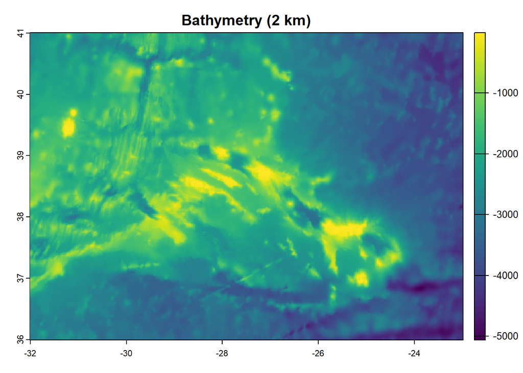

```r
bathy_example <- terra::rast("data/depth_2km.asc")   # bathymetry
slope_example <- terra::rast("data/slope_2km.asc")   # slope

plot(bathy_example, main = "Bathymetry (2 km)")
```

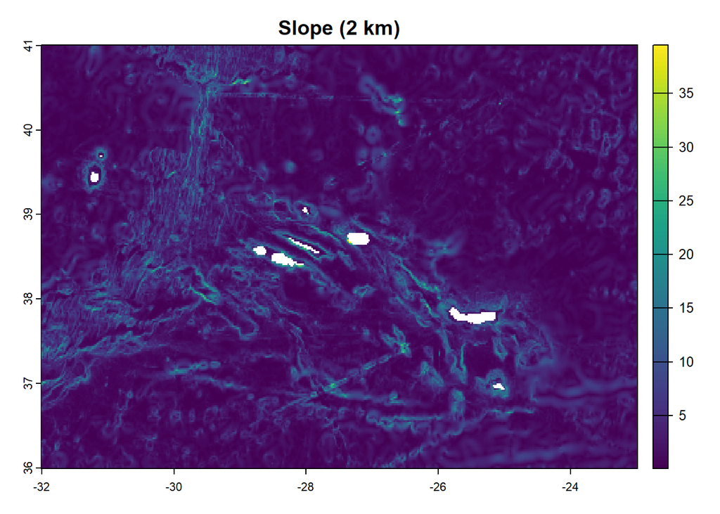

```r
plot(slope_example,  main = "Slope (2 km)")
```

# Download from direct link

We can also import a zipped shapefile straight from GitHub—here, global shipping lanes:

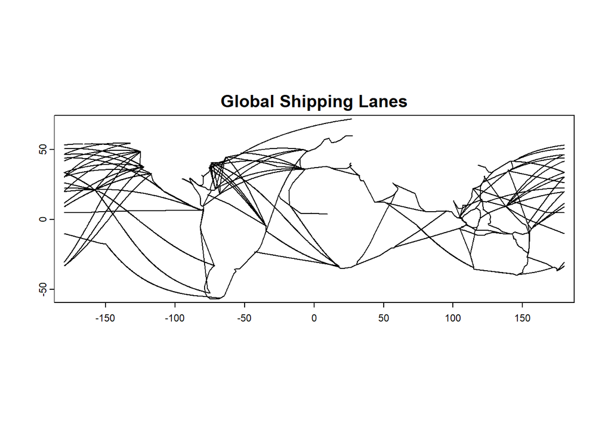

```r
ship_routes <- vect(
  "https://github.com/newzealandpaul/Shipping-Lanes/raw/main/data/Shipping-Lanes-v1/Shipping-Lanes-v1.shp"
)

plot(ship_routes, main = "Global Shipping Lanes")
```

# Import environmental data through sdmpredictors package

In the following, we will focus on downloading environmental data through the *sdmpredictors* package. This package lets you browse, filter and instantly download a wide range of ready-to-use environmental layers — terrestrial and marine predictors — from global collections such as Bio-ORACLE, MARSPEC and WorldClim. With a couple of lines of code you can list available variables, pick just the layers you need (e.g. mean sea-surface temperature or dissolved oxygen), and fetch them as *SpatRaster* or *Raster* objects.

```r
all_datasets <- list_datasets(terrestrial = TRUE, marine = TRUE)
head(all_datasets)
```

```
##   dataset_code terrestrial marine                              url
## 1    WorldClim        TRUE  FALSE        http://www.worldclim.org/
## 2   Bio-ORACLE       FALSE   TRUE          https://bio-oracle.org/
## 3      MARSPEC       FALSE   TRUE              http://marspec.org/
## 4      ENVIREM        TRUE  FALSE       https://envirem.github.io/
## 5   Freshwater        TRUE  FALSE https://www.earthenv.org/streams
##                                                                                                                                                                                                                                                                                                          …
## 1                                                                                                                                                                                                                                                                                                        …
## 2                                                                                                                                                                                                                                                                                                        …
## 3 MARSPEC is a set of high resolution climatic and geophysical GIS data layers for the world ocean. Seven geophysical variables were derived from the SRTM30_PLUS high resolution bathymetry dataset.  These layers characterize the horizontal orientation (aspect), slope, and curvature of the seafloo…
## 4                                                                                                                                 The ENVIREM dataset is a set of 16 climatic and 2 topographic variables that can be used in modeling species' distributions. The strengths of this dataset include thei…
## 5                                                      The dataset consists of near-global, spatially continuous, and freshwater-specific environmental variables in a standardized 1km grid. We delineated the sub-catchment for each grid cell along the HydroSHEDS river network and summarized the up…
##                                                                                                                                                                                                                                   citation
## 1                                   Hijmans, R.J., S.E. Cameron, J.L. Parra, P.G. Jones and A. Jarvis, 2005. Very high resolution interpolated climate surfaces for global land areas. International Journal of Climatology 25: 1965-1978.
## 2 Tyberghein L., Verbruggen H., Pauly K., Troupin C., Mineur F. & De Clerck O. Bio-ORACLE: a global environmental dataset for marine species distribution modeling. Global Ecology and Biogeography. doi: 10.1111/j.1466-8238.2011.00656.x
## 3                                                                                                      Sbrocco, EJ and Barber, PH (2013) MARSPEC: Ocean climate layers for marine spatial ecology. Ecology 94: 979. doi: 10.1890/12-1358.1
## 4                       Title, P.O., Bemmels, J.B. 2017. ENVIREM: An expanded set of bioclimatic and topographic variables increases flexibility and improves performance of ecological niche modeling. Ecography doi: 10.1111/ecog.02880.
## 5                                 Domisch, S., Amatulli, G., and Jetz, W. (2015) Near-global freshwater-specific environmental variables for biodiversity analyses in 1 km resolution. Scientific Data 2:150073 doi: 10.1038/sdata.2015.73
```

above we see the collections from where we can download our environmental data. Since we are not interested in terrestrial data, lets set terrestrial to false!

```r
marine_datasets <- list_datasets(terrestrial = FALSE, marine = TRUE)
head(marine_datasets)
```

```
##   dataset_code terrestrial marine                     url
## 2   Bio-ORACLE       FALSE   TRUE https://bio-oracle.org/
## 3      MARSPEC       FALSE   TRUE     http://marspec.org/
##                                                                                                                                                                                                                                                                                                          …
## 2                                                                                                                                                                                                                                                                                                        …
## 3 MARSPEC is a set of high resolution climatic and geophysical GIS data layers for the world ocean. Seven geophysical variables were derived from the SRTM30_PLUS high resolution bathymetry dataset.  These layers characterize the horizontal orientation (aspect), slope, and curvature of the seafloo…
##                                                                                                                                                                                                                                   citation
## 2 Tyberghein L., Verbruggen H., Pauly K., Troupin C., Mineur F. & De Clerck O. Bio-ORACLE: a global environmental dataset for marine species distribution modeling. Global Ecology and Biogeography. doi: 10.1111/j.1466-8238.2011.00656.x
## 3                                                                                                      Sbrocco, EJ and Barber, PH (2013) MARSPEC: Ocean climate layers for marine spatial ecology. Ecology 94: 979. doi: 10.1890/12-1358.1
```

As we see, we have two collections of data available, MARSPEC and Bio-Oracle. Importantly, whenever you use this kind of data for publication, make sure to cite it!

```r
subset(marine_datasets, select = c("dataset_code", "citation"))
```

```
##   dataset_code
## 2   Bio-ORACLE
## 3      MARSPEC
##                                                                                                                                                                                                                                   citation
## 2 Tyberghein L., Verbruggen H., Pauly K., Troupin C., Mineur F. & De Clerck O. Bio-ORACLE: a global environmental dataset for marine species distribution modeling. Global Ecology and Biogeography. doi: 10.1111/j.1466-8238.2011.00656.x
## 3                                                                                                      Sbrocco, EJ and Barber, PH (2013) MARSPEC: Ocean climate layers for marine spatial ecology. Ecology 94: 979. doi: 10.1890/12-1358.1
```

With the list_layers function of the sdmpredictors package, we can see all the environmental layers that we have available for download

```r
marine_layers <- sdmpredictors::list_layers(datasets = marine_datasets)
```

Now, let us download and plot three MARSPEC layers. We will check out bathymetry, sea-surface salinity and temperature

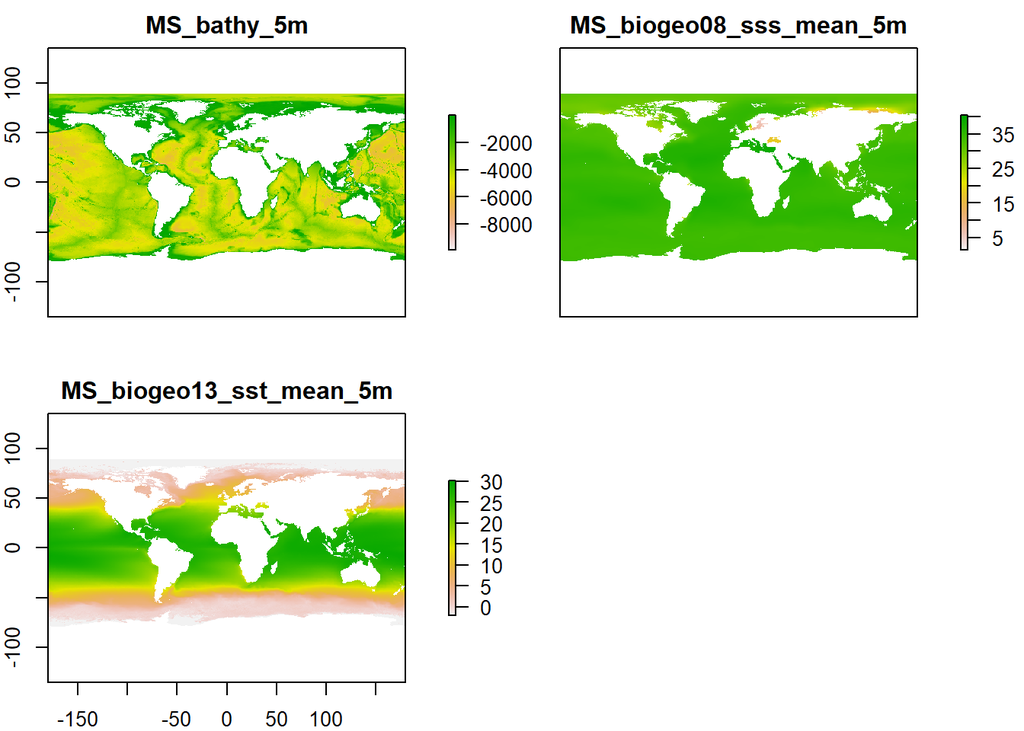

```r
marspec_codes <- c(
  "MS_bathy_5m",                  # bathymetry
  "MS_biogeo08_sss_mean_5m",      # mean sea-surface salinity
  "MS_biogeo13_sst_mean_5m"       # mean sea-surface temperature
)

marspec_data <- sdmpredictors::load_layers(
  marspec_codes,
  datadir = "outputs/sdmpredictors/marspec"
)

terra::plot(marspec_data)
```

Next, let’s do the same for the Bio-Oracle data. You might have noticed that Bio-Oracle has more environmental layers available. Besides bathymetry, salinity, and temperature, let’s download chlorophyll a, a very important predictor for cetaceans!

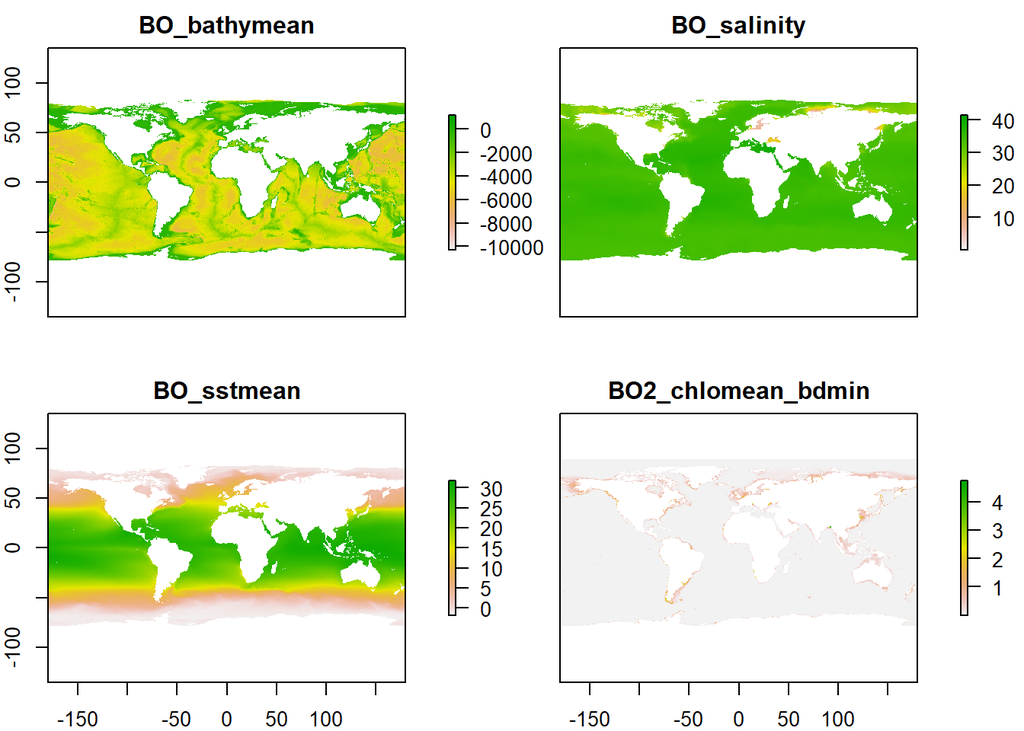

```r
bioracle_codes <- c(
  "BO_bathymean",
  "BO_salinity",
  "BO_sstmean",
  "BO2_chlomean_bdmin"
)
bioracle_data <- sdmpredictors::load_layers(
  bioracle_codes,
  datadir = "outputs/sdmpredictors/bioracle"
)
# Plot the Bio-ORACLE stack:
terra::plot(bioracle_data, main = names(bioracle_data))
```

In the next step, since we have been using global maps of environmental data so far, but in most cases we don’t work on a global scale, we will crop our study extent. Here we will crop the extent to three island groups in the NE Atlantic, but feel free to adapt to your study extent of interest!

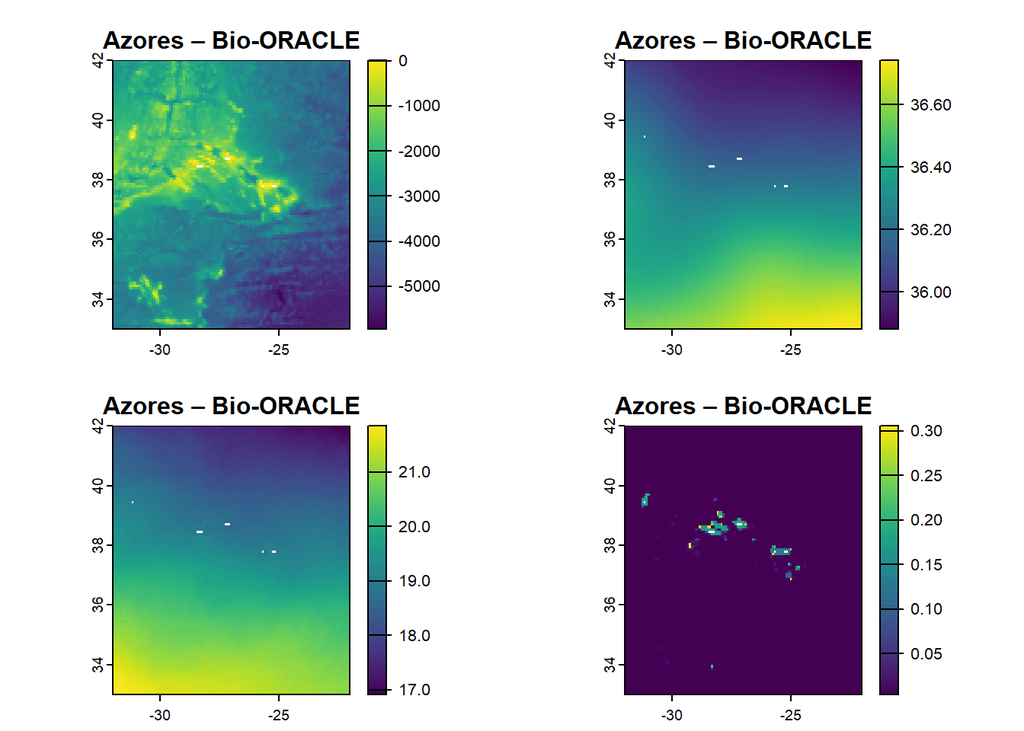

```r
# We have to convert our bioracle_data from a rasterStack to a SpatRaster to continue working in terra
bioracle_data <- terra::rast(bioracle_data)

azores_extent   <- ext(-32, -22, 33, 42)
canaries_extent <- ext(-20, -13, 26, 30)
madeira_extent  <- ext(-18, -16, 32, 34)

azores_bio   <- crop(bioracle_data, azores_extent)
canaries_bio <- crop(bioracle_data, canaries_extent)
madeira_bio  <- crop(bioracle_data, madeira_extent)

plot(azores_bio,   main = "Azores – Bio-ORACLE")
```

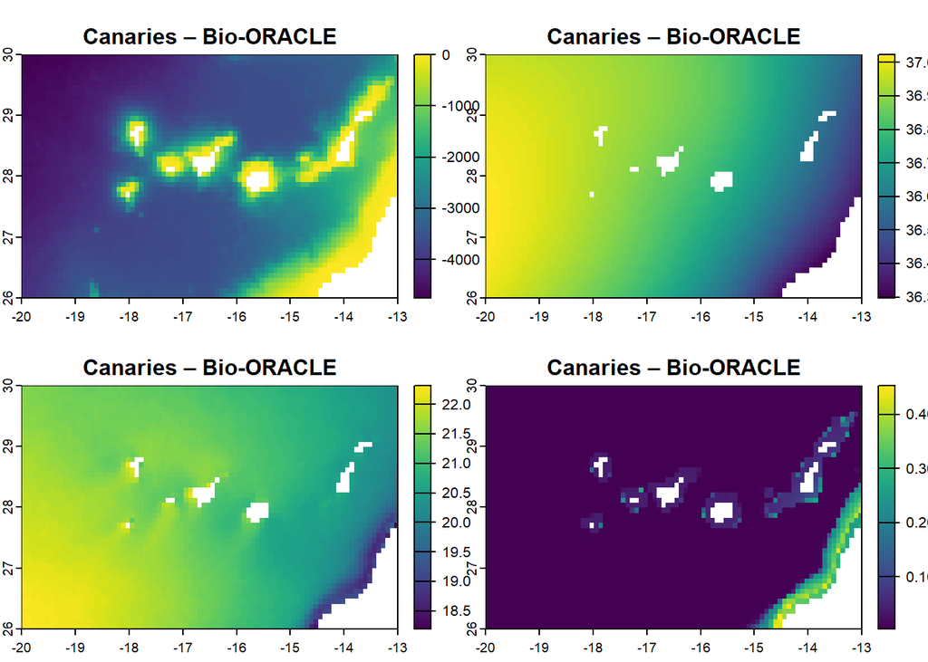

```r
plot(canaries_bio, main = "Canaries – Bio-ORACLE")
```

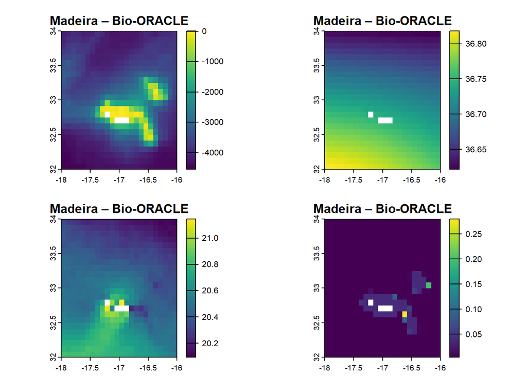

```r
plot(madeira_bio,  main = "Madeira – Bio-ORACLE")
```

You see how we go to smaller spatial extents, the grids become increasingly visible? Let’s find out our grid resolution!

```r
res(bioracle_data)
```

```
## [1] 0.08333333 0.08333333
```

Our layers are stored at 5 arc-minutes, about 9 × 9 km near the equator.

# 7 Combine PA points with environmental predictors

Finally, we’ll walk through a straightforward way to merge environmental predictor values with your presence-absence points, leaving you with an analysis-ready dataset for modelling.

```r
pa_data <- read.csv(
  "data/presence_absence_dataset.csv",
  stringsAsFactors = FALSE
)
head(pa_data)
```

```
##       ID PA   lat   lon        x         y
## 1 215995  1 38.14 -8.96 662017.9 -67456.29
## 2 215996  1 41.33 -9.27 606459.2 283801.75
## 3 215997  1 39.31 -9.55 600631.9  58102.76
## 4 215998  1 40.40 -9.42 602240.5 179751.87
## 5 216000  1 40.18 -9.07 633861.4 157761.17
## 6 216001  1 39.31 -9.55 600631.9  58102.76
```

We will explain this dataset structure in more detail later, for now what’s important is that if PA = 1, it stands for a presence. If PA = 0, it stands for an absence record. lat and lon refer to latitude and longitude in degrees, and x and y are the corresponding coordinates in meters.

Next, we have to turn the dataframe *pa_data* to a spatial object:

```r
pa_points <- vect(
  pa_data,
  geom = c("lon", "lat"),
  crs  = "EPSG:4326"     # WGS-84
)
```

Let’s have a quick look at our *pa_points*

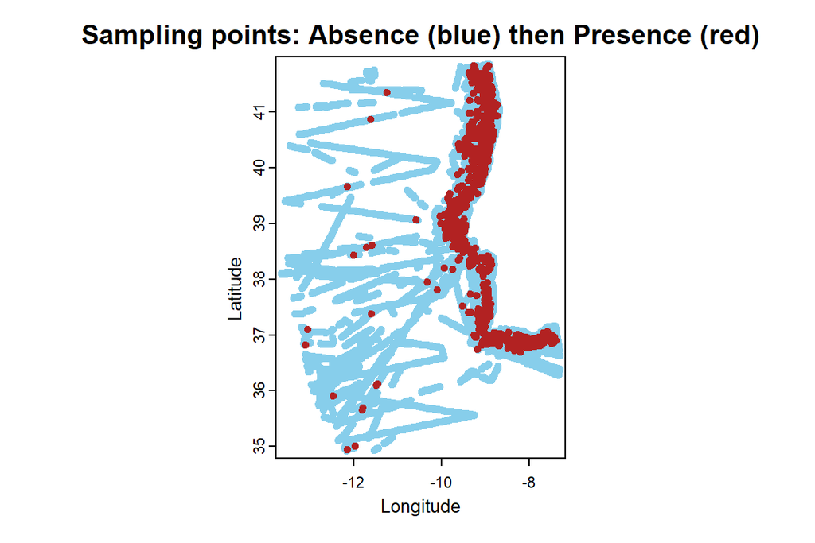

```r
# Split into absence vs presence
absences  <- pa_points[pa_points$PA == 0, ]
presences <- pa_points[pa_points$PA == 1, ]

# 1) Plot absences (blue) first
terra::plot(
  absences,
  col   = "skyblue",
  pch   = 20,
  main  = "Sampling points: Absence (blue) then Presence (red)",
  xlab  = "Longitude",
  ylab  = "Latitude"
)

# 2) Add presences (red) on top
terra::plot(
  presences,
  add   = TRUE,
  col   = "firebrick",
  pch   = 20
)
```

Perfect! Now remember, for each absence (blue) and presence (red) location, we want to know our environmental conditions. We can do this with the following code:

```r
env_values <- terra::extract(
  x    = bioracle_data,
  y    = pa_points,
  bind = FALSE
)
head(env_values)
```

```
##   ID BO_bathymean BO_salinity BO_sstmean BO2_chlomean_bdmin
## 1  1         -125      36.028     16.955           0.127184
## 2  2         -749      35.734     16.051           0.015020
## 3  3          -65      35.708     16.215           0.358635
## 4  4         -149      35.788     16.484           0.062005
## 5  5          -61      35.624     16.057           0.377183
## 6  6          -65      35.708     16.215           0.358635
```

```r
pa_env <- cbind(
  pa_data,
  env_values[, -1, drop = FALSE]  # drop the extract() ID column
)
head(pa_env)
```

```
##       ID PA   lat   lon        x         y BO_bathymean BO_salinity BO_sstmean
## 1 215995  1 38.14 -8.96 662017.9 -67456.29         -125      36.028     16.955
## 2 215996  1 41.33 -9.27 606459.2 283801.75         -749      35.734     16.051
## 3 215997  1 39.31 -9.55 600631.9  58102.76          -65      35.708     16.215
## 4 215998  1 40.40 -9.42 602240.5 179751.87         -149      35.788     16.484
## 5 216000  1 40.18 -9.07 633861.4 157761.17          -61      35.624     16.057
## 6 216001  1 39.31 -9.55 600631.9  58102.76          -65      35.708     16.215
##   BO2_chlomean_bdmin
## 1           0.127184
## 2           0.015020
## 3           0.358635
## 4           0.062005
## 5           0.377183
## 6           0.358635
```

```r
# 7.6 Save combined presence–absence + environmental dataset:
write.csv(
  pa_env,
  file      = "outputs/pa_env_data.csv",
  row.names = FALSE
)
```

SCRIPT COMPLETE! 🎉 We now have our data ready for modelling!